# Kappa multinomial

# This is a brief tutorial for using $\kappa_{multinomial}$, a new way to assess the performance of multinomial predictions for landcover

$\kappa_{multinomial}$ is a metric to assess the performance of multinomial models. Increasingly, land cover models use multinomial models to predict occurence of discrete classes. At present, no suitable mesure exist to evaluate the agreement of such models with observations.

This package provides a method $\kappa_{multinomial}$ to assess the agreement between multinomial models (i.e. those that predict an occurence probability for classes of outcomes) and observations which have either discrete outcomes or outcomes represented by frequencies.

We start with an example to illustrate the use of $\kappa_{multinomial}$. We proceed with some syntethic datasets to get insight in the behaviour of $\kappa_{multinomial}$. The example shows observed mosaic of vegetation types and predicted probabilities of the four dominant vegetation types (Grassland, Shrubland, Broadleaf forest, and Conifer forest) in the Chaparral in California. The predicted probabilities were fitted simultaneously in a multinomial logistic model, and the probabilities of the four vegetation types in a pixel sum to one. Species composition in this area is partly determined by constant factors (such as topology, soil, and climate), and partly stochastic factors such as fire. For full model specifications we refer to Ackerly, D.D., Cornwell, W.K., Weiss, S.B., Flint, L.E. & Flint, A.L. (2015) A Geographic Mosaic of Climate Change Impacts on Terrestrial Vegetation: Which Areas Are Most at Risk? PLoS ONE, 10, e0130629.

First install the packages.

```r
#install.packages("devtools")
devtools::install_github("bobdouma/kappa_multinomial")
library(multinomialperform)
#install.packages("gtools")
library(gtools)
library(grDevices)
```

```r
load("obs_mod_brick.Rdata")
obs
```

```
## class       : RasterLayer
## dimensions  : 290, 322, 93380  (nrow, ncol, ncell)
## resolution  : 3e-04, 3e-04  (x, y)
## extent      : -122.7727, -122.6761, 38.54845, 38.63545  (xmin, xmax, ymin, ymax)
## coord. ref. : NA
## data source : in memory
## names       : layer.1
## values      : 1, 4  (min, max)
```

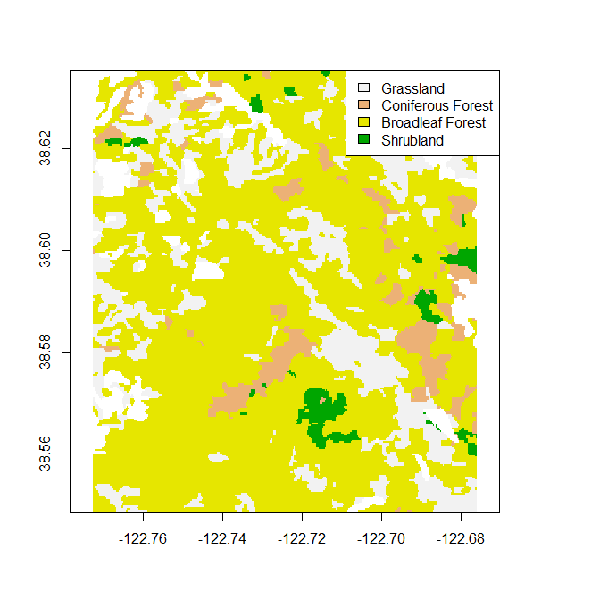

```r
plot(obs,legend=F,col = rev(terrain.colors(4)))
 legend("topright", legend = c("Grassland", "Coniferous Forest", "Broadleaf Forest", "Shrubland"), fill = rev(terrain.colors(4)))
```

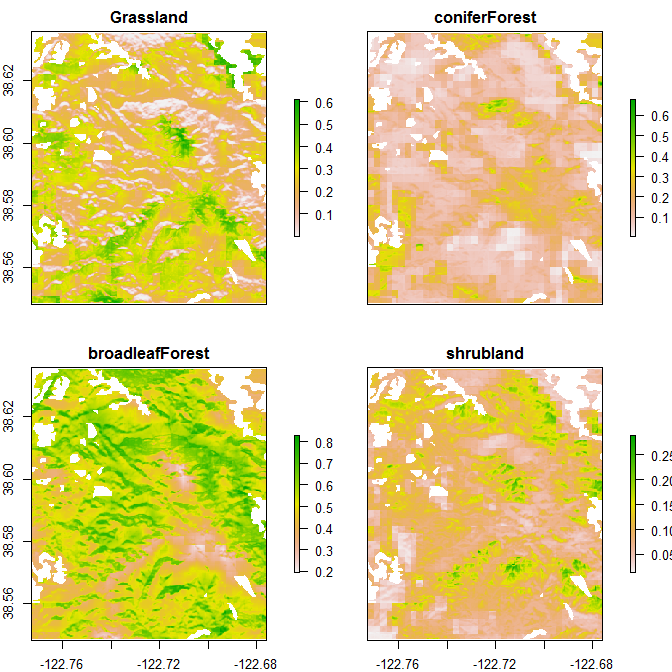

```r
plot(vmap)
```

```r
pred.dat = values(vmap)
obs.dat = values(obs.map)
# remove nas
obs.dat = obs.dat[!is.na(apply(obs.dat,1,sum)),]
pred.dat = pred.dat[!is.na(apply(pred.dat,1,sum)),]
# calculate statistic
kappa_multinomial(obs.dat,pred.dat)
```

```
##     k_prob      k_loc k_multinomial       po        pe      pmax
##  -4.364814 0.03419908    -0.1492726 0.447523 0.5192812 0.5357213
```

In this example the model does not fit the data very well. $\kappa_{multinomial}$ is very low which is mainly due to the fact that $\kappa_{prob}$ is low. Apparently, the observed classes are not predicted with the highest probability.

## Synthetic data

In the simplest case there is a matrix (or data frame) of predictions and a data frame of observations. Both of these can either be binary or continuous probablities. But all cells of both matrixes must be $0<=y_{i}<=1$. The columns of both matrices correspond to $q$ land cover classes. Each row is a sample $i$. Further for the modelled class probabilities and the class observations it should hold that $\sum_{k=1}^q y_{ik} =1$ and $\sum_{k=1}^m p_{ik} = 1$.Not that one of the advances of this approach is that uncertainty in the observations can be represented. The order of the rows for the land cover classes in the observed and predicted matrices should correspond exactly.

$\kappa_{prob}$ measures the degree to which ranks of the predicted class probabilities correspond to the ranks of the observed class frequencies. It thus reaches one if there is a perfect match between the rank orders of the observations and predictions. It reaches zero if the model has similar performance compared to the null model. $\kappa_{loc}$ in turn, measures the certainty of the model in the case of discrete observations. For continuous observations, $\kappa_{loc}$ measures the mean match of the sorted observed and predicted sample frequencies. $\kappa_{loc}$ equals zero if the performance of the multinomial equals the null model. It equals one if, for each sample, the sorted predictions exactly matches the sorted observations.

### Case 1: Predictions are continuous probabilities and observations discrete

In this case we show an example where the observed classes are predicted to be most likely. This implies that $\kappa_{prob}$ should equal to one and $\kappa_{loc}$ will depend on the average certainty with which the observed classes are predited

```r
pred = as.data.frame(rdirichlet(100, c(0.1,0.1,0.5,0.5))) # generate multinomial probabilties with four classes
pred = t(apply(pred,1,sample)) # randomly shuffles the columns for each sample; otherwise only one class is most likely
obs = as.data.frame(prob_to_binary(pred)) # prob_to_binary transforms probabilities to discrete outcomes, 1 for the most probable class, 0's for the remaining classes
kappa_multinomial(obs=obs,pred=pred) # calculate kappa
```

```
##  k_prob     k_loc k_multinomial        po     pe      pmax
##       1 0.6338325     0.6338325 0.7314528 0.2666 0.7314528
```

### Case 2: Predictions are continuous probabilities and observations discrete

In this case we show an example where the observed classes are predicted to be most likely. However, the certainty with which the classes are predicted is much higher. Again, $\kappa_{prob}$ should equal to one and $\kappa_{loc}$ will depend on the average certainty with which the observed classes are predited

```r
pred = as.data.frame(rdirichlet(100, c(0.1,0.1,4.5,0.5))) # generate multinomial probabilties with four classes
pred = t(apply(pred,1,sample))
obs = as.data.frame(prob_to_binary(pred))
kappa_multinomial(obs=obs,pred=pred) # calculate kappa
```

```
##  k_prob     k_loc k_multinomial        po     pe      pmax
##       1 0.7992675     0.7992675 0.8508959 0.2572 0.8508959
```

### Case 3: Predictions are continuous probabilities and observations discrete

In this case we show an example where there is mismatch between the observed classes and the classes predicted to be most likely. $\kappa_{loc}$ remains similar as the previous example. However $\kappa_{prob}$ becomes lower than one.

```r
obs = as.data.frame(prob_to_binary(pred))  # transform probs to 0,1 (1 being the most likely)
resample = sample(c(1:100),20) # randomly pick 20 observations
obs[resample,] = obs[sample(resample),] # randomly shuffle 20 observations
kappa_multinomial(obs=obs,pred=pred) # calculate kappa
```

```
##     k_prob     k_loc k_multinomial        po     pe      pmax
##  0.7982676 0.7992675     0.6380293 0.7311282 0.2572 0.8508959
```

### Case 4: Predictions are continuous probabilities and observations not discrete

In this case we show an example wehere prediction frequency is equal to observed frequency. In this case _{multinomial} should equal 1, indicating perfect model performance.

```r
pred = as.data.frame(rdirichlet(100, c(0.1,0.1,0.5,0.5))) # generate multinomial probabilties with four classes
obs = pred
kappa_multinomial(obs=obs,pred=pred) # calculate kappa
```

```
## [1] "Observations are not discrete. A randomization procedure is used to calculate pe. Consider adjusting nsim"
## ========================================================================================================================
```

```
##  k_prob k_loc k_multinomial po        pe pmax
##       1     1             1  1 0.4963882    1
```

### Case 5: Observations not discrete and prediction frequency random relative to observed

In this case the evaluation of the model should find that $\kappa_{prob}$ preforms poorly, while the maximum model fit of a model with this set of modelled class distributions for the set of observations, $\kappa_{loc}$ is one.

```r
pred = as.data.frame(rdirichlet(100, c(0.1,0.1,0.5,0.5))) # generate multinomial probabilties with four classes
obs = as.data.frame(t(apply(pred,1,sample))) # randomly shuffle observations
kappa_multinomial(obs=obs,pred=pred,nsim=10000) # calculate kappa
```

```
## [1] "Observations are not discrete. A randomization procedure is used to calculate pe. Consider adjusting nsim"
## ========================================================================================================================
```

```
##     k_prob k_loc k_multinomial       po        pe pmax
##  0.1098369     1     0.1098369 0.408366 0.3353645    1
```

### Case 6: Observations not discrete and the most likely class to be observed is predicted with lower probability. However the ranking within a sample remains the same.

Observations not discrete: The observations are generated such that the class predicted with higest probability is observed to be a bit less likely (val). The ranking of the sample probabilities remain the same; hence $\kappa_{prob}$ is close to one (not exactly because if the class that is predicted with highest probablity is smaller than the second highest class after subtracting val than the ranking is changed). In contrast $\kappa_{loc}$ decreases.

```r
increase = function(x,val=0.05){
  for (i in 1:nrow(x)){
  x[i,which.max(x[i,])] =  x[i,which.max(x[i,])] - val
  x[i,-which.max(x[i,])] = x[i,-which.max(x[i,])]+   val/(ncol(x)-1)
  }
  return(x)
}

pred = as.data.frame(rdirichlet(100, c(0.1,0.1,0.5,0.5))) # generate multinomial probabilties with four classes
obs = pred # randomly shuffle observations

pred.lower= increase(pred,val=0.1)

kappa_multinomial(obs=obs,pred=pred) # calculate kappa
```

```
## [1] "Observations are not discrete. A randomization procedure is used to calculate pe. Consider adjusting nsim"
## ========================================================================================================================
```

```
##  k_prob k_loc k_multinomial po        pe pmax
##       1     1             1  1 0.5094966    1
```

```r
kappa_multinomial(obs=obs,pred=pred.lower) # calculate kappa
```

```
## [1] "Observations are not discrete. A randomization procedure is used to calculate pe. Consider adjusting nsim"
## ========================================================================================================================
```

```
##     k_prob     k_loc k_multinomial        po        pe      pmax
##  0.9968868 0.8077103     0.8051957 0.9043333 0.5089088 0.9055682
```